# Doing Survival Analysis in R

Mick Cooney

June 2016

# 1 Introduction

This document illustrates some basic uses of survival analysis for modelling lapses on a book of life insurance policies.

We assume a basic understanding of survival analysis. For further information on this topic, see [Jon Sedar’s blogpost series](http://blog.applied.ai/survival-analysis-part1/).

# 2 Load Data

```r
dt_protection <- readRDS('dt_protection.rds')
dt_inforce    <- dt_protection[policy_status == 'inforce']

head(dt_protection)
```

```
##     policy_id   countyname                edname       nuts3name      sa_id
## 1: C000100025  Galway City              Claddagh            West A068005008
## 2: C000100030 Kerry County                 Caher South-West (IE) A077035011
## 3: C000100048 South Dublin Rathfarnham-Hermitage          Dublin A267115004
## 4: C000100055  Cork County         Youghal Rural South-West (IE) A047322003
## 5: C000100081 South Dublin  Clondalkin-Monastery          Dublin A267050029
## 6: C000100112  Dublin City             Ashtown A          Dublin A268006005
##    cluster_id  prod_type prem_type prem_freq prem_ape prem_risk
## 1:      n6_c4 protection        RP        12   767.40   548.143
## 2:      n6_c0 protection        RP        12  1017.50   726.787
## 3:      n6_c0 protection        RP        12 19037.33 13598.094
## 4:      n6_c2 protection        RP        12 28630.20 20450.142
## 5:      n6_c0 protection        RP        12  1232.92   880.659
## 6:      n6_c4 protection        RP        12   835.27   596.619
##    policy_startdate policy_enddate policy_duration mort_rating sum_assured
```

[output cut: 27 more lines]

```r
head(dt_inforce)
```

```
##     policy_id       countyname                          edname       nuts3name
## 1: C000100030     Kerry County                           Caher South-West (IE)
## 2: C000100055      Cork County                   Youghal Rural South-West (IE)
## 3: C000100112      Dublin City                       Ashtown A          Dublin
## 4: C000100150 Roscommon County                          Creagh            West
## 5: C000100183  Limerick County                       Knocklong        Mid-West
## 6: C000100237   Kildare County Droichead Nua (Newbridge) Rural        Mid-East
##         sa_id cluster_id  prod_type prem_type prem_freq prem_ape prem_risk
## 1: A077035011      n6_c0 protection        RP        12  1017.50   726.787
## 2: A047322003      n6_c2 protection        RP        12 28630.20 20450.142
## 3: A268006005      n6_c4 protection        RP        12   835.27   596.619
## 4: A197045004      n6_c1 protection        RP        12   305.05   217.890
## 5: A127103004      n6_c2 protection        RP        12 10645.86  7604.185
## 6: A087033002      n6_c5 protection        RP        12  3634.54  2596.102
##    policy_startdate policy_enddate policy_duration mort_rating sum_assured
```

[output cut: 27 more lines]

# 3 Create Kaplan-Meier Estimates

First we build a few different KM estimates: for the overall dataset, for gender and for smoker.

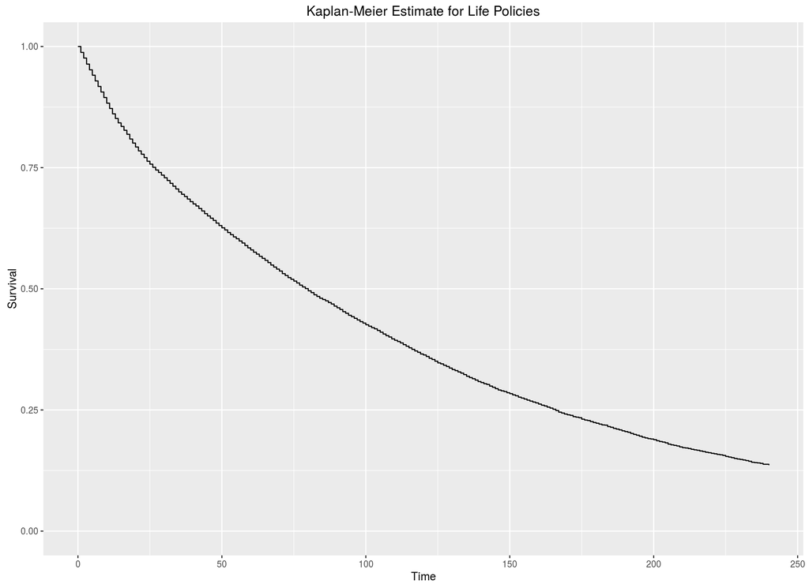

```r
lapse_km_overall <- survfit(Surv(durmaxrch, lapsed) ~ 1, data = dt_protection)

ggsurv(lapse_km_overall, plot.cens = FALSE, CI = FALSE) +
    expand_limits(y = 0) +
    ggtitle("Kaplan-Meier Estimate for Life Policies")
```

Now we look at gender

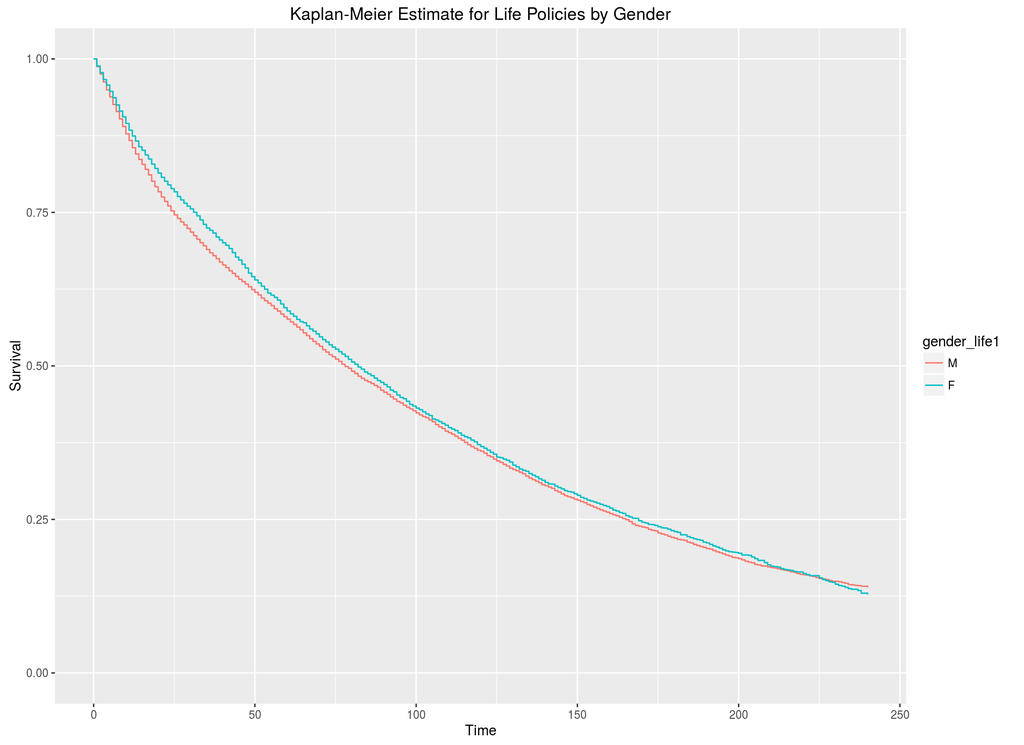

```r
lapse_km_gender <- survfit(Surv(durmaxrch, lapsed) ~ gender_life1, data = dt_protection)

ggsurv(lapse_km_gender, plot.cens = FALSE) +
    expand_limits(y = 0) +
    ggtitle("Kaplan-Meier Estimate for Life Policies by Gender")
```

And finally smoker

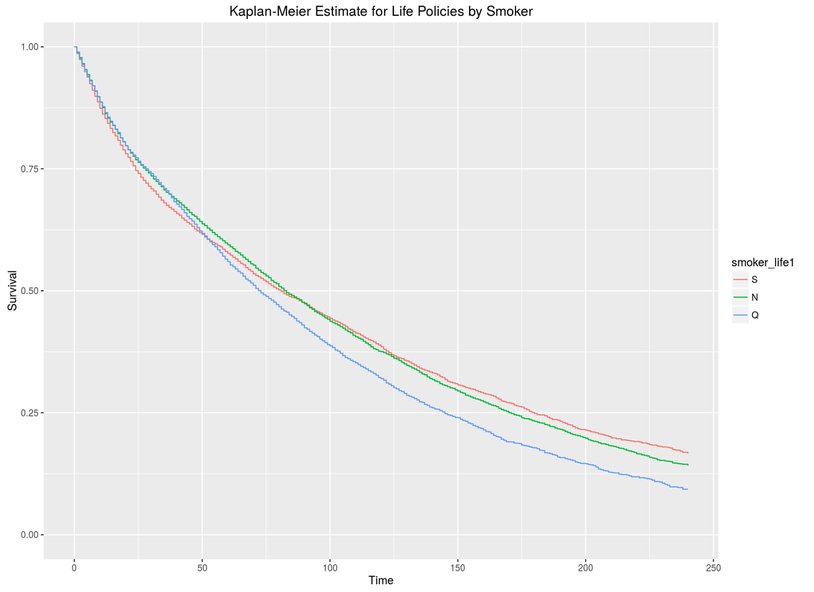

```r
lapse_km_smoker <- survfit(Surv(durmaxrch, lapsed) ~ smoker_life1, data = dt_protection)

ggsurv(lapse_km_smoker, plot.cens = FALSE) +
    expand_limits(y = 0) +
    ggtitle("Kaplan-Meier Estimate for Life Policies by Smoker")
```

# 4 Build Basic Cox-PH Model

We build some basic Cox-PH models and look at the output. We will also look at various splits of the data and see if we can induce the effects of time-varying parameters by splitting the data into groups.

```r
surv_formula <- formula(Surv(durmaxrch, lapsed) ~ gender_life1 + smoker_life1 +
    mortgage_status + cluster_id + prem_ape)

lapse_coxph <- coxph(surv_formula, data = dt_protection)

summary(lapse_coxph)
```

```
## Call:
## coxph(formula = surv_formula, data = dt_protection)
##
##   n= 23208, number of events= 13992
##
##                              coef exp(coef)  se(coef)     z Pr(>|z|)
## gender_life1M            6.95e-02  1.07e+00  1.90e-02  3.65  0.00026 ***
## smoker_life1Q            1.40e-01  1.15e+00  2.10e-02  6.67  2.6e-11 ***
## smoker_life1S            7.03e-03  1.01e+00  2.06e-02  0.34  0.73259
## mortgage_statusMORTDECR  1.62e-02  1.02e+00  1.80e-02  0.90  0.36725
## mortgage_statusMORTFULL -1.53e-02  9.85e-01  3.07e-02 -0.50  0.61931
## cluster_idn6_c1         -1.18e-02  9.88e-01  2.91e-02 -0.41  0.68436
## cluster_idn6_c2         -1.08e-02  9.89e-01  2.72e-02 -0.40  0.69206
## cluster_idn6_c3          2.52e-04  1.00e+00  3.64e-02  0.01  0.99448
## cluster_idn6_c4         -1.48e-01  8.62e-01  3.12e-02 -4.75  2.0e-06 ***
## cluster_idn6_c5          2.74e-01  1.31e+00  2.38e-02 11.51  < 2e-16 ***
## prem_ape                -9.87e-07  1.00e+00  6.13e-07 -1.61  0.10771
## ---
## Signif. codes:  0 '***' 0.001 '**' 0.01 '*' 0.05 '.' 0.1 ' ' 1
##
##                         exp(coef) exp(-coef) lower .95 upper .95
## gender_life1M               1.072      0.933     1.033     1.113
## smoker_life1Q               1.150      0.870     1.104     1.198
## smoker_life1S               1.007      0.993     0.967     1.048
## mortgage_statusMORTDECR     1.016      0.984     0.981     1.053
## mortgage_statusMORTFULL     0.985      1.015     0.927     1.046
## cluster_idn6_c1             0.988      1.012     0.933     1.046
## cluster_idn6_c2             0.989      1.011     0.938     1.044
## cluster_idn6_c3             1.000      1.000     0.931     1.074
## cluster_idn6_c4             0.862      1.160     0.811     0.917
## cluster_idn6_c5             1.315      0.761     1.255     1.378
## prem_ape                    1.000      1.000     1.000     1.000
##
## Concordance= 0.542  (se = 0.003 )
## Rsquare= 0.015   (max possible= 1 )
## Likelihood ratio test= 341  on 11 df,   p=0
## Wald test            = 349  on 11 df,   p=0
## Score (logrank) test = 352  on 11 df,   p=0
```

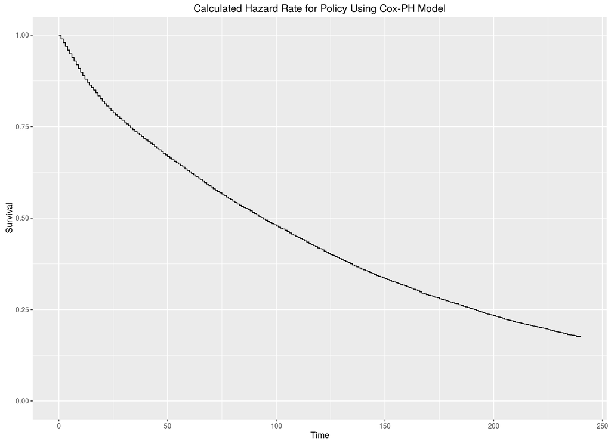

```r
dt_baseline <- data.table(gender_life1 = 'F'
                         ,smoker_life1 = 'N'
                         ,mortgage_status = '00TERM'
                         ,cluster_id      = 'n6_c0'
                         ,prem_ape        = mean(dt_protection$prem_ape))

ggsurv(survfit(lapse_coxph, newdata = dt_baseline)
              ,plot.cens = FALSE, CI = FALSE) +
    expand_limits(y = 0) +

    ggtitle("Calculated Hazard Rate for Policy Using Cox-PH Model")
```

`ggsurv` does not seem to work for CoxPH objects like `plot` does in base R, so instead we can use the output of survfit directly to plot the survival curves - this might be worth trying to contribute to GGally at some point.

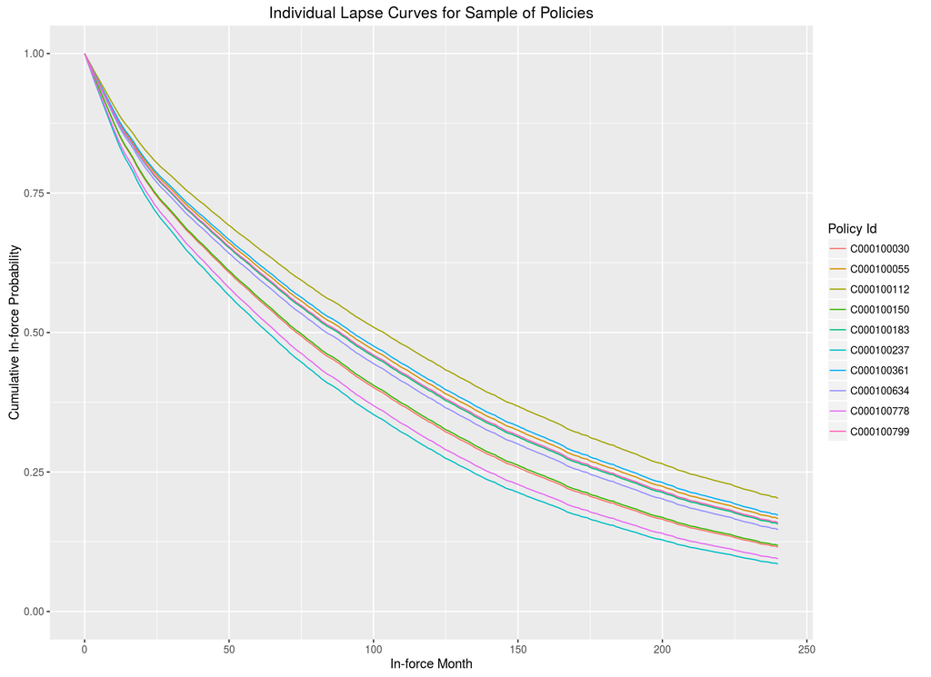

```r
lapse_curves <- survfit(lapse_coxph, newdata = dt_inforce)$surv

lapse_curves <- rbind(rep(1, ncol(lapse_curves))
                     ,lapse_curves)

colnames(lapse_curves) <- dt_inforce$policy_id

ggplot(data = melt(lapse_curves[,1:10])) +
    geom_line(aes(x = Var1 - 1, y = value, group = Var2, colour = Var2)) +
    expand_limits(y = 0) +
    xlab("In-force Month") +
    ylab("Cumulative In-force Probability") +
    guides(color = guide_legend(title = 'Policy Id')) +
    ggtitle("Individual Lapse Curves for Sample of Policies")
```

## 4.1 Look at Strata

One aspect of the Cox-PH model that is also worth exploring is the use of ‘stratified’ analysis: this is where we use different baseline hazard rates for different groupings of the data based on some categorical data.

How much of an impact does this have on our output?

First we stratify the Cox-PH model by gender

```r
lapse_strata_gender_coxph <- coxph(Surv(durmaxrch, lapsed) ~ strata(gender_life1) +
                                       smoker_life1 + mortgage_status + cluster_id +
                                       prem_ape
                                  ,data = dt_protection)

summary(lapse_strata_gender_coxph)
```

```
## Call:
## coxph(formula = Surv(durmaxrch, lapsed) ~ strata(gender_life1) +
##     smoker_life1 + mortgage_status + cluster_id + prem_ape, data = dt_protection)
##
##   n= 23208, number of events= 13992
##
##                              coef exp(coef)  se(coef)     z Pr(>|z|)
## smoker_life1Q            1.40e-01  1.15e+00  2.09e-02  6.68  2.4e-11 ***
## smoker_life1S            6.36e-03  1.01e+00  2.06e-02  0.31     0.76
## mortgage_statusMORTDECR  1.58e-02  1.02e+00  1.80e-02  0.88     0.38
## mortgage_statusMORTFULL -1.40e-02  9.86e-01  3.07e-02 -0.46     0.65
## cluster_idn6_c1         -1.16e-02  9.88e-01  2.91e-02 -0.40     0.69
## cluster_idn6_c2         -1.02e-02  9.90e-01  2.72e-02 -0.37     0.71
## cluster_idn6_c3         -3.04e-05  1.00e+00  3.64e-02  0.00     1.00
## cluster_idn6_c4         -1.47e-01  8.63e-01  3.12e-02 -4.72  2.4e-06 ***
## cluster_idn6_c5          2.74e-01  1.32e+00  2.38e-02 11.52  < 2e-16 ***
## prem_ape                -9.99e-07  1.00e+00  6.14e-07 -1.63     0.10
## ---
## Signif. codes:  0 '***' 0.001 '**' 0.01 '*' 0.05 '.' 0.1 ' ' 1
##
##                         exp(coef) exp(-coef) lower .95 upper .95
## smoker_life1Q               1.150      0.869     1.104     1.198
## smoker_life1S               1.006      0.994     0.967     1.048
## mortgage_statusMORTDECR     1.016      0.984     0.981     1.052
## mortgage_statusMORTFULL     0.986      1.014     0.928     1.047
## cluster_idn6_c1             0.988      1.012     0.934     1.047
## cluster_idn6_c2             0.990      1.010     0.938     1.044
## cluster_idn6_c3             1.000      1.000     0.931     1.074
## cluster_idn6_c4             0.863      1.159     0.812     0.917
## cluster_idn6_c5             1.315      0.760     1.255     1.378
## prem_ape                    1.000      1.000     1.000     1.000
##
## Concordance= 0.54  (se = 0.004 )
## Rsquare= 0.014   (max possible= 1 )
## Likelihood ratio test= 335  on 10 df,   p=0
## Wald test            = 344  on 10 df,   p=0
## Score (logrank) test = 347  on 10 df,   p=0
```

```r
## ggsurv(survfit(lapse_strata_gender_coxph, newdata = dt_baseline)
##               ,plot.cens = FALSE, CI = FALSE) +
##     expand_limits(y = 0) +
##     ggtitle("Calculated Hazard Rate for Policy Using Cox-PH Model")
```

Now we stratify by smoker

```r
lapse_strata_smoker_coxph <- coxph(Surv(durmaxrch, lapsed) ~ gender_life1 +
                                       strata(smoker_life1) + mortgage_status +
                                       cluster_id + prem_ape
                                  ,data = dt_protection)

summary(lapse_strata_smoker_coxph)
```

```
## Call:
## coxph(formula = Surv(durmaxrch, lapsed) ~ gender_life1 + strata(smoker_life1) +
##     mortgage_status + cluster_id + prem_ape, data = dt_protection)
##
##   n= 23208, number of events= 13992
##
##                              coef exp(coef)  se(coef)     z Pr(>|z|)
## gender_life1M            6.85e-02  1.07e+00  1.90e-02  3.60  0.00032 ***
## mortgage_statusMORTDECR  1.52e-02  1.02e+00  1.80e-02  0.84  0.39911
## mortgage_statusMORTFULL -1.41e-02  9.86e-01  3.07e-02 -0.46  0.64609
## cluster_idn6_c1         -9.16e-03  9.91e-01  2.91e-02 -0.31  0.75305
## cluster_idn6_c2         -8.26e-03  9.92e-01  2.72e-02 -0.30  0.76172
## cluster_idn6_c3          1.03e-03  1.00e+00  3.64e-02  0.03  0.97735
## cluster_idn6_c4         -1.47e-01  8.63e-01  3.12e-02 -4.72  2.4e-06 ***
## cluster_idn6_c5          2.75e-01  1.32e+00  2.38e-02 11.58  < 2e-16 ***
## prem_ape                -9.61e-07  1.00e+00  6.10e-07 -1.58  0.11524
## ---
## Signif. codes:  0 '***' 0.001 '**' 0.01 '*' 0.05 '.' 0.1 ' ' 1
##
##                         exp(coef) exp(-coef) lower .95 upper .95
## gender_life1M               1.071      0.934     1.032     1.112
## mortgage_statusMORTDECR     1.015      0.985     0.980     1.052
## mortgage_statusMORTFULL     0.986      1.014     0.928     1.047
## cluster_idn6_c1             0.991      1.009     0.936     1.049
## cluster_idn6_c2             0.992      1.008     0.940     1.046
## cluster_idn6_c3             1.001      0.999     0.932     1.075
## cluster_idn6_c4             0.863      1.159     0.812     0.917
## cluster_idn6_c5             1.317      0.759     1.257     1.380
## prem_ape                    1.000      1.000     1.000     1.000
##
## Concordance= 0.542  (se = 0.005 )
## Rsquare= 0.013   (max possible= 1 )
## Likelihood ratio test= 299  on 9 df,   p=0
## Wald test            = 307  on 9 df,   p=0
## Score (logrank) test = 310  on 9 df,   p=0
```

```r
## ggsurv(survfit(lapse_strata_gender_coxph, newdata = dt_baseline)
##               ,plot.cens = FALSE, CI = FALSE) +
##     expand_limits(y = 0) +
##     ggtitle("Calculated Hazard Rate for Policy Using Cox-PH Model")
```

Now we stratify by gender and smoker

```r
lapse_strata_both_coxph <- coxph(Surv(durmaxrch, lapsed) ~ strata(gender_life1) +
                                       strata(smoker_life1) + mortgage_status +
                                       cluster_id + prem_ape
                                ,data = dt_protection)

summary(lapse_strata_both_coxph)
```

```
## Call:
## coxph(formula = Surv(durmaxrch, lapsed) ~ strata(gender_life1) +
##     strata(smoker_life1) + mortgage_status + cluster_id + prem_ape,
##   ...
##
##   n= 23208, number of events= 13992
##
##                              coef exp(coef)  se(coef)     z Pr(>|z|)
## mortgage_statusMORTDECR  1.43e-02  1.01e+00  1.80e-02  0.79     0.43
## mortgage_statusMORTFULL -1.50e-02  9.85e-01  3.07e-02 -0.49     0.62
## cluster_idn6_c1         -8.42e-03  9.92e-01  2.91e-02 -0.29     0.77
## cluster_idn6_c2         -8.64e-03  9.91e-01  2.73e-02 -0.32     0.75
## cluster_idn6_c3          2.91e-04  1.00e+00  3.64e-02  0.01     0.99
## cluster_idn6_c4         -1.48e-01  8.62e-01  3.13e-02 -4.74  2.1e-06 ***
## cluster_idn6_c5          2.76e-01  1.32e+00  2.38e-02 11.58  < 2e-16 ***
## prem_ape                -9.43e-07  1.00e+00  6.10e-07 -1.55     0.12
## ---
## Signif. codes:  0 '***' 0.001 '**' 0.01 '*' 0.05 '.' 0.1 ' ' 1
##
##                         exp(coef) exp(-coef) lower .95 upper .95
## mortgage_statusMORTDECR     1.014      0.986     0.979     1.051
## mortgage_statusMORTFULL     0.985      1.015     0.928     1.046
## cluster_idn6_c1             0.992      1.008     0.937     1.050
## cluster_idn6_c2             0.991      1.009     0.940     1.046
## cluster_idn6_c3             1.000      1.000     0.931     1.074
## cluster_idn6_c4             0.862      1.160     0.811     0.917
## cluster_idn6_c5             1.317      0.759     1.257     1.380
## prem_ape                    1.000      1.000     1.000     1.000
##
## Concordance= 0.537  (se = 0.006 )
## Rsquare= 0.012   (max possible= 1 )
## Likelihood ratio test= 286  on 8 df,   p=0
## Wald test            = 294  on 8 df,   p=0
## Score (logrank) test = 296  on 8 df,   p=0
```

```r
## ggsurv(survfit(lapse_strata_gender_coxph, newdata = dt_baseline)
##               ,plot.cens = FALSE, CI = FALSE) +
##     expand_limits(y = 0) +
##     ggtitle("Calculated Hazard Rate for Policy Using Cox-PH Model")
```

# 5 Time-Dependent Cox-PH by Data Splitting

We also want to split each of the periods of time into blocks of 12 months at a time and then run similar models on each one. The function `survSplit` does most of the heavy lifting on this.

```r
dt_split <- survSplit(Surv(durmaxrch, lapsed) ~ .
                     ,data = dt_protection
                     ,cut = 12 * 1:35
                     ,start   = 'start_month'
                     ,episode = 'block_id'
                      )
setDT(dt_split)

dt_split <- dt_split[, .(policy_id
                        ,start_month
                        ,stop_month  = durmaxrch
                        ,lapsecol    = lapsed
                        ,block_id)]

dt_splitdata <- merge(dt_protection
                     ,dt_split
                     ,by = 'policy_id')

dim(dt_splitdata)
```

```
## [1] 141869     32
```

```r
head(dt_splitdata)
```

```
##     policy_id  countyname   edname nuts3name      sa_id cluster_id  prod_type
## 1: C000100025 Galway City Claddagh      West A068005008      n6_c4 protection
## 2: C000100025 Galway City Claddagh      West A068005008      n6_c4 protection
## 3: C000100025 Galway City Claddagh      West A068005008      n6_c4 protection
## 4: C000100025 Galway City Claddagh      West A068005008      n6_c4 protection
## 5: C000100025 Galway City Claddagh      West A068005008      n6_c4 protection
## 6: C000100025 Galway City Claddagh      West A068005008      n6_c4 protection
##    prem_type prem_freq prem_ape prem_risk policy_startdate policy_enddate
## 1:        RP        12    767.4   548.143       1993-02-25     2013-02-25
## 2:        RP        12    767.4   548.143       1993-02-25     2013-02-25
## 3:        RP        12    767.4   548.143       1993-02-25     2013-02-25
## 4:        RP        12    767.4   548.143       1993-02-25     2013-02-25
## 5:        RP        12    767.4   548.143       1993-02-25     2013-02-25
## 6:        RP        12    767.4   548.143       1993-02-25     2013-02-25
##    policy_duration mort_rating sum_assured  dob_life1 gender_life1 smoker_life1
```

[output cut: 27 more lines]

Now that we have built our dataset to split out the different time blocks, I run the same CoxPH model on each separate block of data:

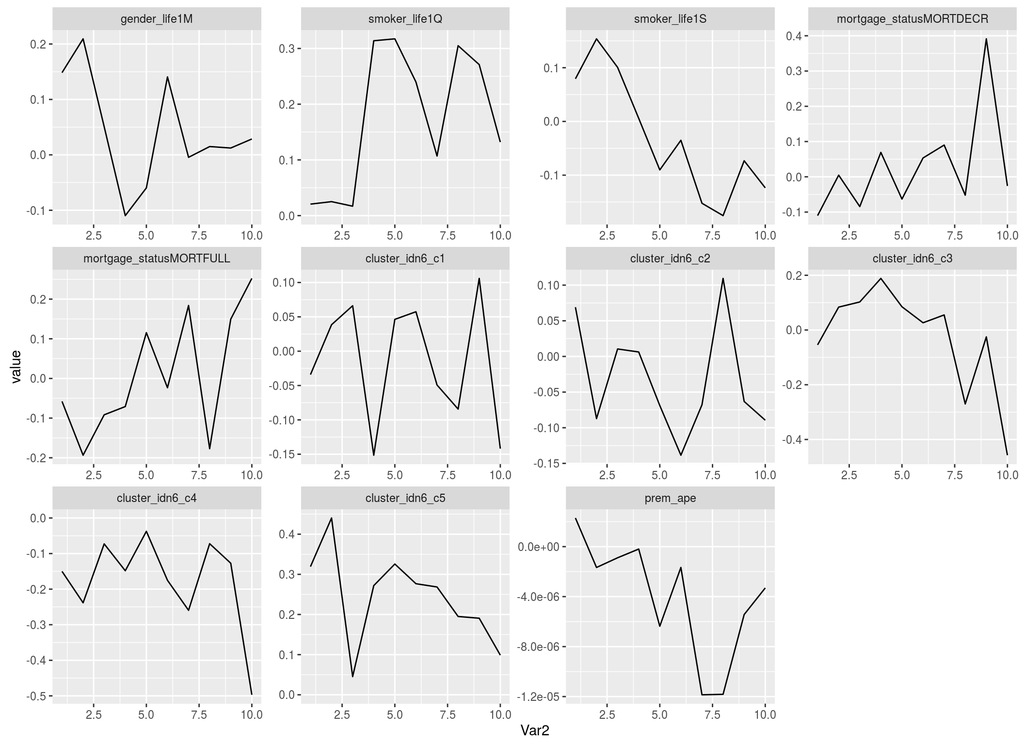

```r
timedata <- sapply(1:10, function(iterid) {
    block_coxph <- coxph(Surv(start_month, stop_month, lapsecol) ~
                             gender_life1 + smoker_life1 + mortgage_status +
                             cluster_id + prem_ape
                        ,data = dt_splitdata[block_id == iterid])

    return(coef(block_coxph))
})

ggplot(data = melt(timedata)) +
    geom_line(aes(x = Var2, y = value)) +
    facet_wrap(~Var1, scales = 'free') +
    expand_limits(y = 0)
```